# Group bias and discrimination

rich-ramsey.github.io/talks/ncm-lab-25/

Richard Ramsey  
[www.rich-ramsey.com](https://rich-ramsey.com)

[figure not shown]

## Big picture research interests

[Le Tricheur à l’as de carreau by Georges de la Tour (c. 1635)]

# Today

**Group bias and discrimination**

[Deschrijver & Ramsey, 2025, *PNAS*](https://www.pnas.org/doi/10.1073/pnas.2413797122)

## Group bias and discrimination

[figure not shown]

[figure not shown]

[figure not shown]

[figure not shown]

[figure not shown]

[figure not shown]

## Minimal groups

[figure not shown]

(Tajfel 1970, 1974)

## The minimal group paradigm

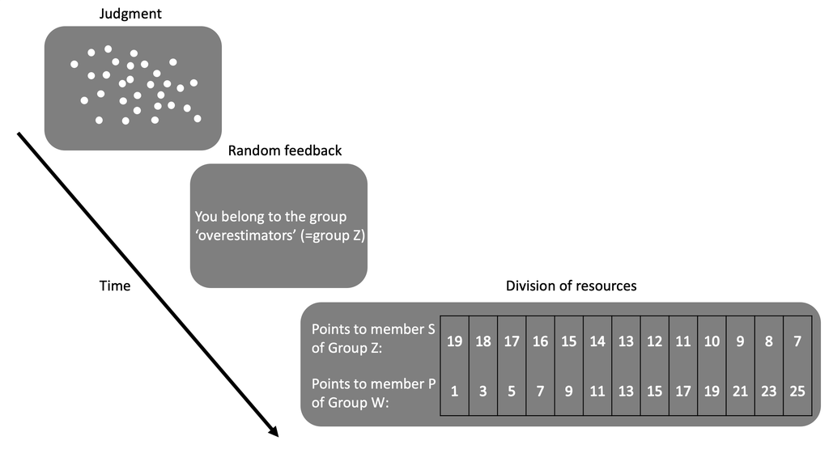

- Assign values to two other specific people (not yourself).
- Select one option (two values).
- Measure so-called “pull” scores.

(Tajfel 1970, 1974)

## Pull scores

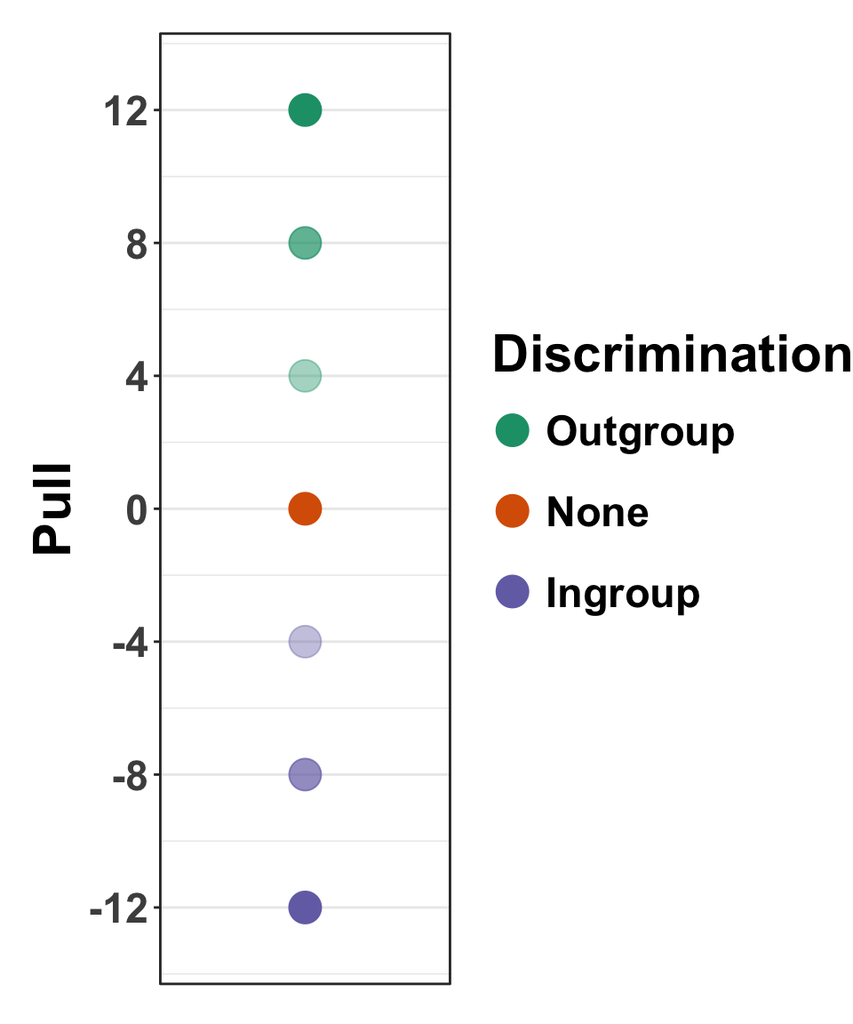

Three types of “pull” score are of interest.

1. FAV vs MJP
2. MD vs MIP/MJP
3. FAV vs P

Each compares a discriminatory strategy against a more pro-social strategy.

## Minimal group findings

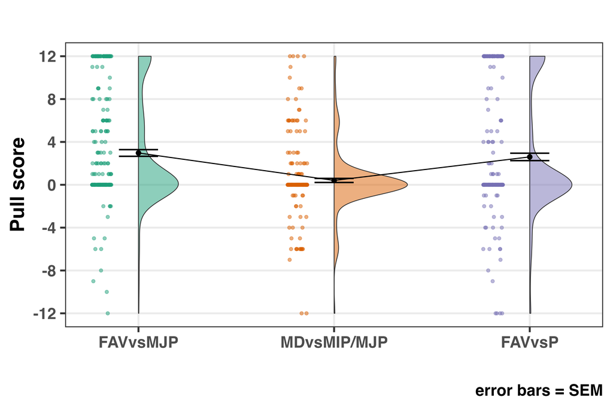

(Schmidt and Drake 2023)

## Minimal group tasks

## mpg-1

## mpg-2

## mpg-3

## mpg-4

## Significance of the work

- Ingroup benefit and outgroup punishment was evident, even in arbitrary or “minimal” conditions.
- Meaningful social categories, such as race, gender, age etc., are not required to discriminate against others.
- It formed a foundation of Social Identity Theory (Tajfel and Turner 1979).

## Groups and social identity theory

> … explicit references to group membership are logically necessary for operationalizing in these minimal situations the major independent variable—that is, social categorization per se.

(Tajfel and Turner 1979 [p. 39])

Citation count: 41,343

## Groups and social identity theory

> This requires not merely that the subjects perceive themselves as similar to or different from others as *individuals*, but that they are members of discrete and discontinuous categories—that is, “groups”.

(Tajfel and Turner 1979 [p. 39]) [*emphasis in the original*]

Citation count: 41,343

## Groups and social identity theory

> It was as if that, just by inserting the word ‘group’ into the experimental instructions, the s’s definition of the situation was radically altered.

(Billig and Tajfel 1973 [p. 48])

Citation count: 2,538

## Confound

A similarity or difference *between individuals* covaries with group assignment.

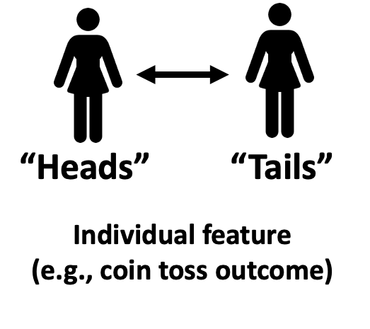

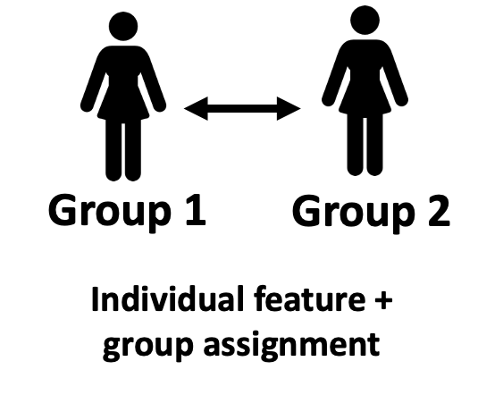

## Conflict signals

- Why might a similarity or difference between individuals matter?
- Cognitive neuroscience research shows that conflict in general is an aversive stimulus that guides behaviour.

| task | congruent | incongruent |
| --- | --- | --- |
| flanker | HHHHH | HHSHH |
| Stroop | RED | RED |

(Botvinick and Braver 2015; Dreisbach and Fischer 2015)

## Conflict signals and groups

- Could sensitivity to conflict between individuals play a role in the minimal group paradigm?

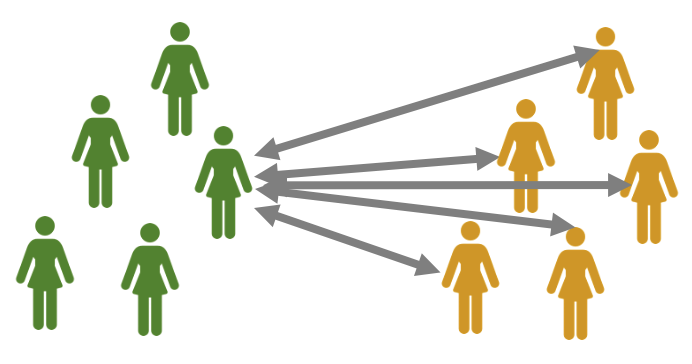

(Deschrijver and Palmer 2020)

## Deschrijver & Ramsey (2025)

**Research question**

Are group division and social identity required to treat people differently?

**Hypothesis**

Resources will be allocated in favour of similar (versus dissimilar) individuals, in the absence of group division or social identity.

## Comparing research designs

**Original design**

**Deschrijver & Ramsey (2025)**

**Arbitrary choices/coin flip**

**Group division / categorisation**

**Money allocation / matrices**

**Arbitrary choices/coin flip**

**Group division / categorisation**

✗

**Money allocation / matrices**

## Group manipulation

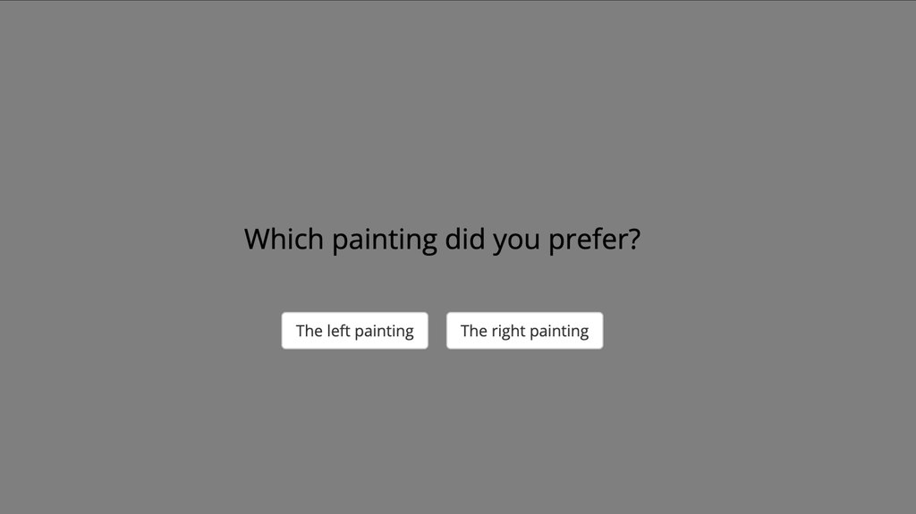

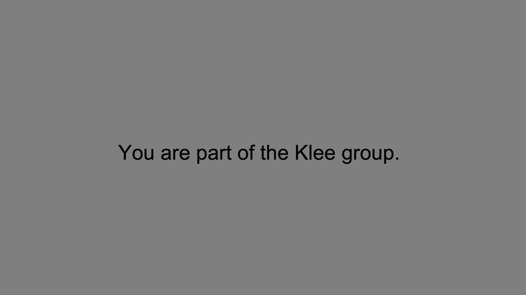

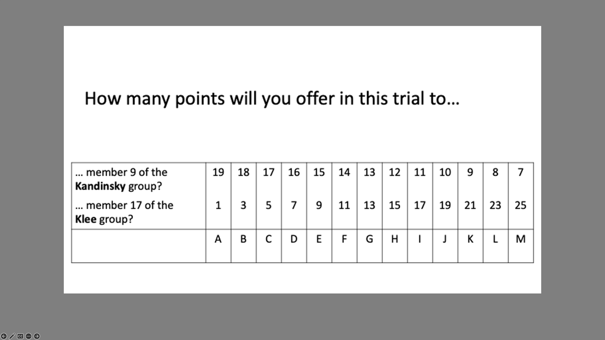

## No group manipulation

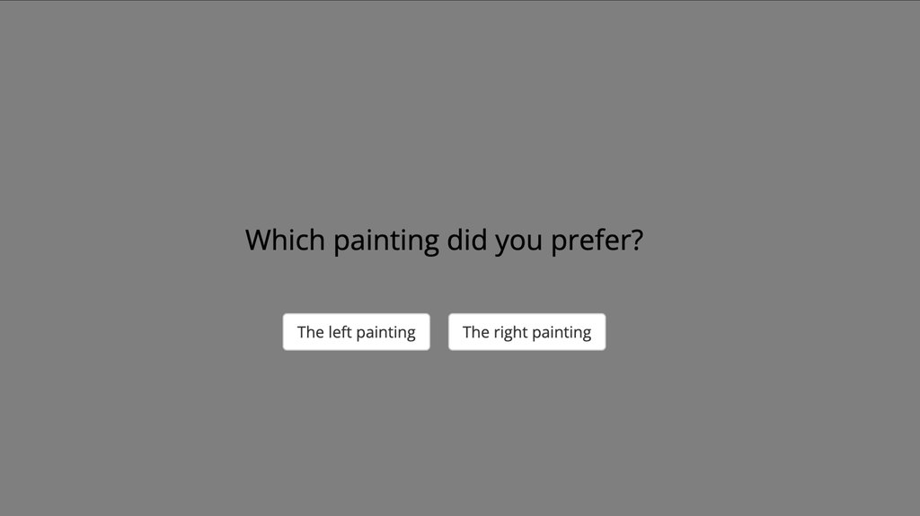

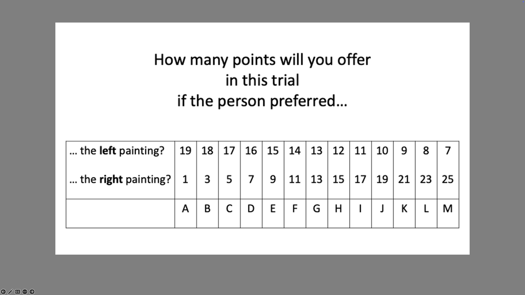

## Comparing response wording

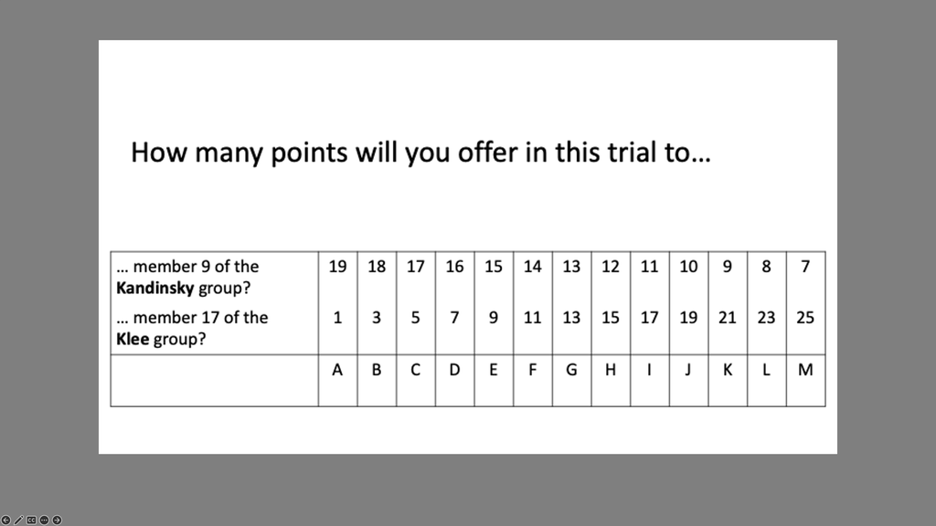

Group manipulation

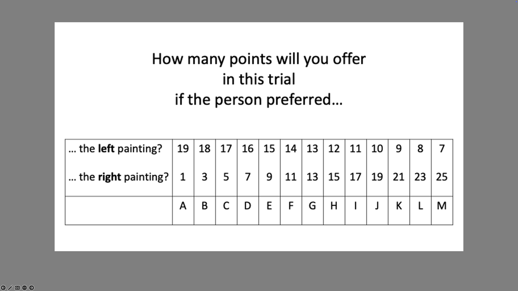

No group manipulation

## deschrijver25-1

## deschrijver25-2

## deschrijver25-3

## Descrijver & Ramsey (2025)

UK-based Prolific online sample. N=238 per experiment.

## Raw data: minimal group dots

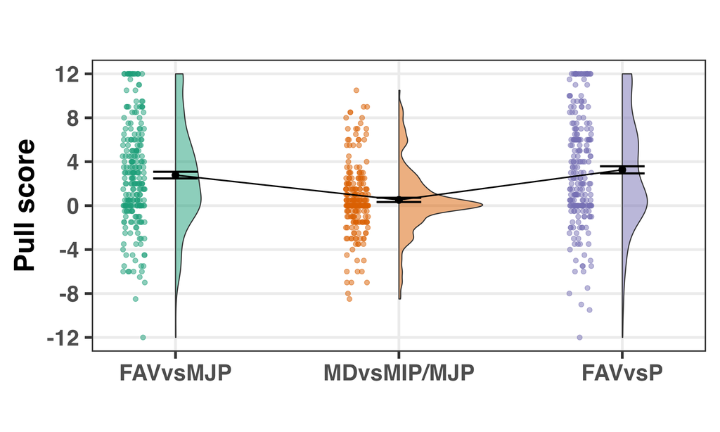

(Deschrijver and Ramsey 2025)

## Regression parameters: minimal group

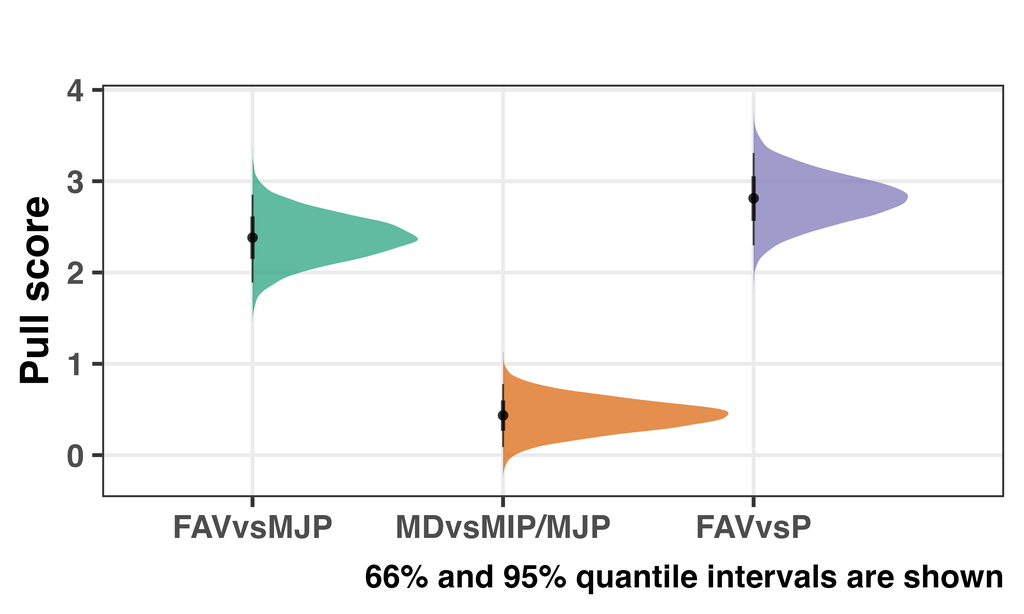

(Deschrijver and Ramsey 2025)

## Individual vs group manipulation

- Between groups design.
  - individual vs classic group manipulation
- Coins task (random outcome).
- N=238 per group (N=476 in total).
- UK-based online Prolific sample.

## Regression parameters: individual vs group

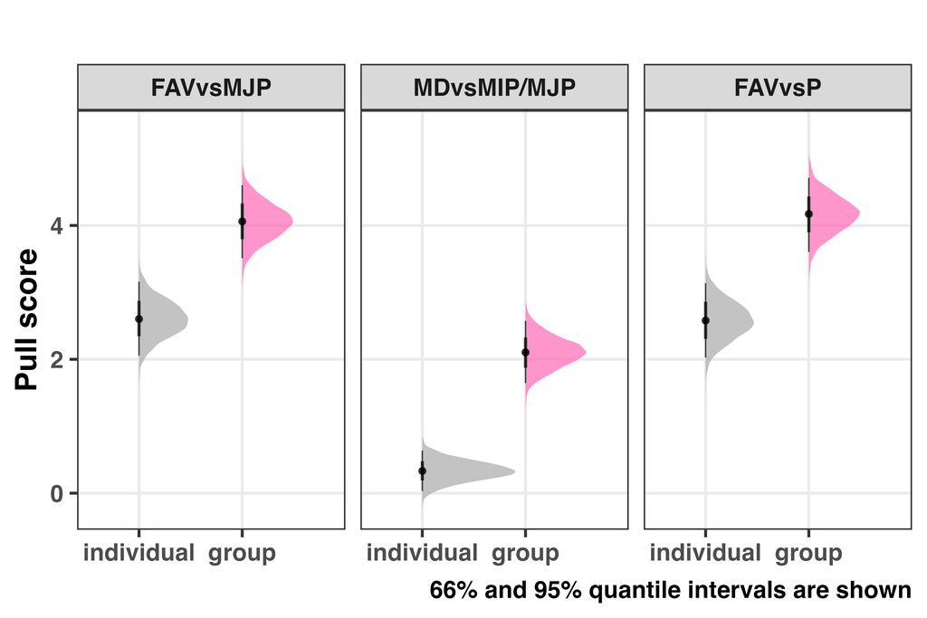

(Deschrijver and Ramsey 2025)

## Interim summary

- Qualitatively similar minimal group paradigm effects are obtained *without group assignment*.
- But the results so far are all tied to one task.
- We wanted to investigate the same type of question with a different task? Maybe a simpler dependent measure?
- We setup a conflict/congruency task based on work in cognitive psychology / neuroscience.

## Conflict task manipulation

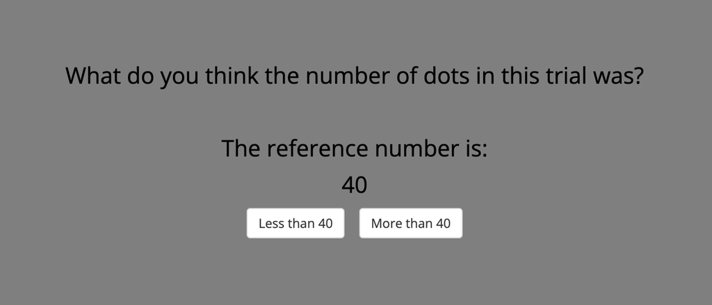

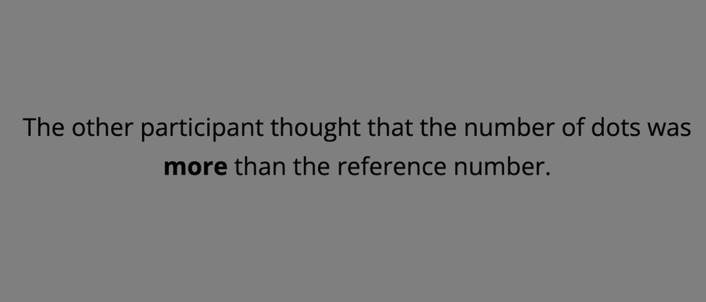

| self/other judgment | condition |
| --- | --- |
| same | congruent |
| different | incongruent |

## Conflict task response

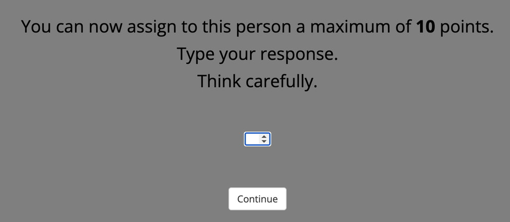

## Congruency trial structure

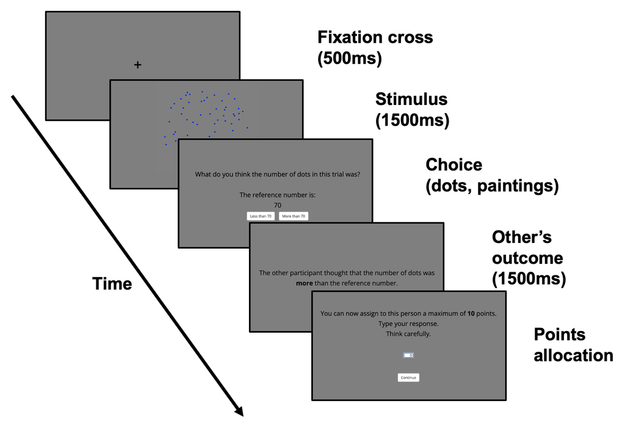

## Descrijver & Ramsey (2025)

UK-based Prolific online sample. N=75 per experiment.

## Congruency hypothesis

**Research question**

Are group division and social identity required to treat people differently?

**Hypothesis**

More money will be allocated to others on congruent than incongruent trials, in the absence of group division or social identity.

## Raw data: congruency

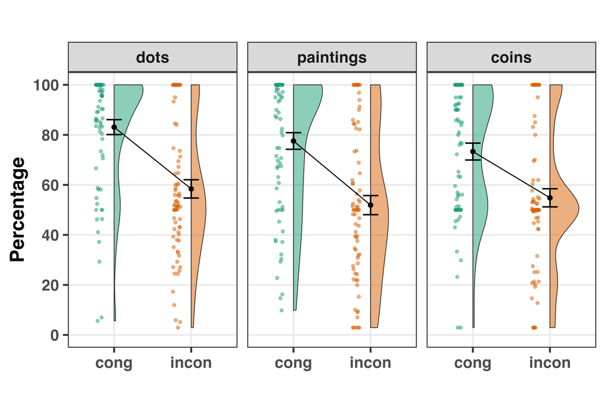

(Deschrijver and Ramsey 2025)

## Regression parameters: congruency

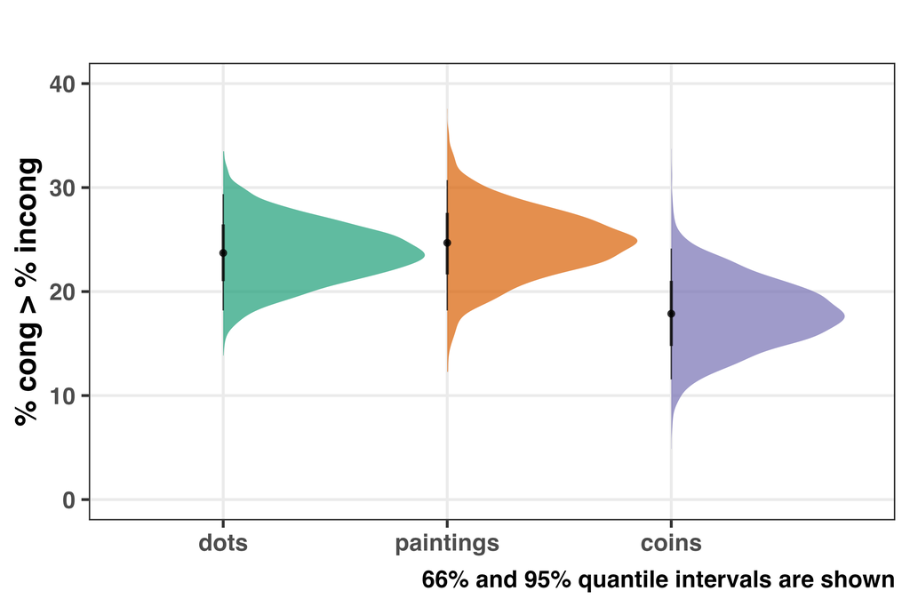

(Deschrijver and Ramsey 2025)